# Project: TMDB Data analysis

- Introduction
- Data Wrangling
- Correlations
- Exploratory Data Analysis
- Conclusions

## Introduction

### Dataset Description

> This data set contains information about 10,000 movies collected from The Movie Database (TMDb), including user ratings and revenue.

> Certain columns, like ‘cast’ and ‘genres’, contain multiple values separated by pipe (|) characters. There are some odd characters in the ‘cast’ column. Don’t worry about cleaning them. You can leave them as is. The final two columns ending with “_adj” show the budget and revenue of the associated movie in terms of 2010 dollars, accounting for inflation over time

Variables:

-id

-imdb_id

-popularity

-budget

-revenue

-original_title

-cast

-homepage

-director

-tagline

-keywords

-overview

-runtime

-genres

-production_companies

-release_date

-vote_count

-vote_average

-release_year

-budget_adj

-revenue_ad

### Question(s) for Analysis

> Question 1:How long is the average movie runtime?

> Question 2:Which year has the highest release of movies?

> Question 3:Which length movies most liked by the audiences according to their popularity?

> Question 4:What is the Average Runtime Of Movies From Year To Year?

> Question 5:Is the rating of movies getting better or worse or staying the same over time?

> Question 6:What is the highest rated movie?

> Question 7:What is the most popular genre over the years?

```python
# Loading libraries
import numpy as np
import pandas as pd
import matplotlib.pyplot as plt
import seaborn as sns
% matplotlib inline
```

## Data Wrangling

Reading csv file

```python
df = pd.read_csv('tmdb-movies.csv')
```

Exploring some stastical data

```python
df.describe()
```

|  | id | popularity | budget | revenue | runtime | vote_count | vote_average | release_year | budget_adj | revenue_adj |
| --- | --- | --- | --- | --- | --- | --- | --- | --- | --- | --- |
| count | 10866.000000 | 10866.000000 | 1.086600e+04 | 1.086600e+04 | 10866.000000 | 10866.000000 | 10866.000000 | 10866.000000 | 1.086600e+04 | 1.086600e+04 |
| mean | 66064.177434 | 0.646441 | 1.462570e+07 | 3.982332e+07 | 102.070863 | 217.389748 | 5.974922 | 2001.322658 | 1.755104e+07 | 5.136436e+07 |
| std | 92130.136561 | 1.000185 | 3.091321e+07 | 1.170035e+08 | 31.381405 | 575.619058 | 0.935142 | 12.812941 | 3.430616e+07 | 1.446325e+08 |
| min | 5.000000 | 0.000065 | 0.000000e+00 | 0.000000e+00 | 0.000000 | 10.000000 | 1.500000 | 1960.000000 | 0.000000e+00 | 0.000000e+00 |
| 25% | 10596.250000 | 0.207583 | 0.000000e+00 | 0.000000e+00 | 90.000000 | 17.000000 | 5.400000 | 1995.000000 | 0.000000e+00 | 0.000000e+00 |
| 50% | 20669.000000 | 0.383856 | 0.000000e+00 | 0.000000e+00 | 99.000000 | 38.000000 | 6.000000 | 2006.000000 | 0.000000e+00 | 0.000000e+00 |
| 75% | 75610.000000 | 0.713817 | 1.500000e+07 | 2.400000e+07 | 111.000000 | 145.750000 | 6.600000 | 2011.000000 | 2.085325e+07 | 3.369710e+07 |
| max | 417859.000000 | 32.985763 | 4.250000e+08 | 2.781506e+09 | 900.000000 | 9767.000000 | 9.200000 | 2015.000000 | 4.250000e+08 | 2.827124e+09 |

Printing first rows to explore data

```python
df.head(3)
```

|  | id | imdb_id | popularity | budget | revenue | original_title | cast | homepage | director | tagline | ... | overview | runtime | genres | production_companies | release_date | vote_count | vote_average | release_year | budget_adj | revenue_adj |
| --- | --- | --- | --- | --- | --- | --- | --- | --- | --- | --- | --- | --- | --- | --- | --- | --- | --- | --- | --- | --- | --- |
| 0 | 135397 | tt0369610 | 32.985763 | 150000000 | 1513528810 | Jurassic World | Chris Pratt\|Bryce Dallas Howard\|Irrfan Khan\|Vi... | http://www.jurassicworld.com/ | Colin Trevorrow | The park is open. | ... | Twenty-two years after the events of Jurassic ... | 124 | Action\|Adventure\|Science Fiction\|Thriller | Universal Studios\|Amblin Entertainment\|Legenda... | 6/9/15 | 5562 | 6.5 | 2015 | 1.379999e+08 | 1.392446e+09 |
| 1 | 76341 | tt1392190 | 28.419936 | 150000000 | 378436354 | Mad Max: Fury Road | Tom Hardy\|Charlize Theron\|Hugh Keays-Byrne\|Nic... | http://www.madmaxmovie.com/ | George Miller | What a Lovely Day. | ... | An apocalyptic story set in the furthest reach... | 120 | Action\|Adventure\|Science Fiction\|Thriller | Village Roadshow Pictures\|Kennedy Miller Produ... | 5/13/15 | 6185 | 7.1 | 2015 | 1.379999e+08 | 3.481613e+08 |
| 2 | 262500 | tt2908446 | 13.112507 | 110000000 | 295238201 | Insurgent | Shailene Woodley\|Theo James\|Kate Winslet\|Ansel... | http://www.thedivergentseries.movie/#insurgent | Robert Schwentke | One Choice Can Destroy You | ... | Beatrice Prior must confront her inner demons ... | 119 | Adventure\|Science Fiction\|Thriller | Summit Entertainment\|Mandeville Films\|Red Wago... | 3/18/15 | 2480 | 6.3 | 2015 | 1.012000e+08 | 2.716190e+08 |

3 rows × 21 columns

### Data Cleaning

1-Here we are going to drop columns that has no use for our questions

2-Check for duplicates

3-drop null values

4-converting release_date from string to datetime

5-dropping zeroes in runtime,budget,revenue using a list

```python
df.drop(['id','imdb_id','homepage','director','tagline','overview','keywords','cast'], axis=1,inplace=True)
```

```python
#dropping NA values
df.dropna(inplace=True)
```

```python
#dropping duplicates
df.drop_duplicates(inplace=True)
```

```python
#confirming changes
df.duplicated().sum()
```

```
0
```

```python
# converting release date from string to datetime format
df['release_date'] =pd.to_datetime(df['release_date'])
```

```python
# list for runtime, budget, revenue columns
data_zero = ['runtime','budget','revenue']

# replacing values from '0' to NAN in the list
df[data_zero] = df[data_zero].replace(0, np.NAN)

#Removing rows which has NaN value in the list
df.dropna(subset = data_zero, inplace = True)
```

## Exploratory Data Analysis

### 1-How long is the average movie runtime ?

```python
df['runtime'].describe()
```

```
count    3808.000000
mean      109.362395
std        19.855757
min        15.000000
25%        96.000000
50%       106.000000
75%       119.000000
max       338.000000
Name: runtime, dtype: float64
```

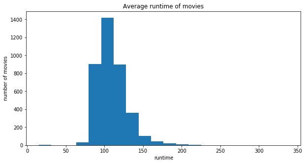

```python
# size of plot
plt.figure(figsize=(10,5))
# x-axis
plt.xlabel('runtime')
# y-axis
plt.ylabel('number of movies')
plt.title('Average runtime of movies')

plt.hist(df['runtime'],bins=20);
```

As we can see in the plot above

Average runtime is: 109 mins

```
25% has less than 96 mins

50% has less than 106 mins

75% has less than 119 mins

min runtime is    15  mins
max runtime is    338 mins
```

```python
df.head()
```

|  | popularity | budget | revenue | original_title | runtime | genres | production_companies | release_date | vote_count | vote_average | release_year | budget_adj | revenue_adj |
| --- | --- | --- | --- | --- | --- | --- | --- | --- | --- | --- | --- | --- | --- |
| 0 | 32.985763 | 150000000.0 | 1.513529e+09 | Jurassic World | 124.0 | Action\|Adventure\|Science Fiction\|Thriller | Universal Studios\|Amblin Entertainment\|Legenda... | 2015-06-09 | 5562 | 6.5 | 2015 | 1.379999e+08 | 1.392446e+09 |
| 1 | 28.419936 | 150000000.0 | 3.784364e+08 | Mad Max: Fury Road | 120.0 | Action\|Adventure\|Science Fiction\|Thriller | Village Roadshow Pictures\|Kennedy Miller Produ... | 2015-05-13 | 6185 | 7.1 | 2015 | 1.379999e+08 | 3.481613e+08 |
| 2 | 13.112507 | 110000000.0 | 2.952382e+08 | Insurgent | 119.0 | Adventure\|Science Fiction\|Thriller | Summit Entertainment\|Mandeville Films\|Red Wago... | 2015-03-18 | 2480 | 6.3 | 2015 | 1.012000e+08 | 2.716190e+08 |
| 3 | 11.173104 | 200000000.0 | 2.068178e+09 | Star Wars: The Force Awakens | 136.0 | Action\|Adventure\|Science Fiction\|Fantasy | Lucasfilm\|Truenorth Productions\|Bad Robot | 2015-12-15 | 5292 | 7.5 | 2015 | 1.839999e+08 | 1.902723e+09 |
| 4 | 9.335014 | 190000000.0 | 1.506249e+09 | Furious 7 | 137.0 | Action\|Crime\|Thriller | Universal Pictures\|Original Film\|Media Rights ... | 2015-04-01 | 2947 | 7.3 | 2015 | 1.747999e+08 | 1.385749e+09 |

## Correlations

### Correlation between profit and revenue

```python
df['gross_profit'] = df['revenue']-df['budget']
df.head(1)
```

|  | popularity | budget | revenue | original_title | runtime | genres | production_companies | release_date | vote_count | vote_average | release_year | budget_adj | revenue_adj | gross_profit |
| --- | --- | --- | --- | --- | --- | --- | --- | --- | --- | --- | --- | --- | --- | --- |
| 0 | 32.985763 | 150000000.0 | 1.513529e+09 | Jurassic World | 124.0 | Action\|Adventure\|Science Fiction\|Thriller | Universal Studios\|Amblin Entertainment\|Legenda... | 2015-06-09 | 5562 | 6.5 | 2015 | 1.379999e+08 | 1.392446e+09 | 1.363529e+09 |

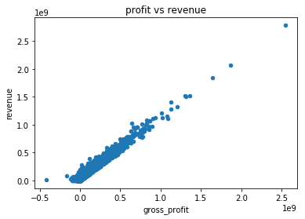

```python
df.plot(x='gross_profit',y='revenue', kind='scatter' , title='profit vs revenue');
```

```python
df['gross_profit'].corr(df['revenue'])
```

```
0.9791469102044178
```

we can see here that there is a strong positive correlation between gross profit and revenue

### Correlation between budget and revenue

```python
bud_rev =df.groupby('budget')['revenue'].mean()
```

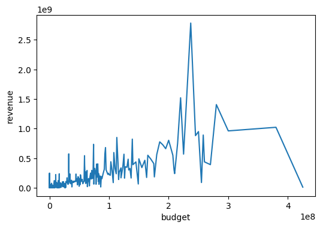

```python
plt.figure(dpi =100)

# x-label
plt.xlabel('budget')

# y-label
plt.ylabel('revenue')


plt.plot(bud_rev)

plt.show()
```

```python
df['budget'].corr(df['revenue'])
```

```
0.68716508126074205
```

As shown in the plot above there is positive correlation between budget and revenue

### 2 - Which year has the highest release of movies ?

```python
highest_year =df.groupby('release_year')['original_title'].count()
highest_year.head(3)
```

```
release_year
1960     5
1961    10
1962     7
Name: original_title, dtype: int64
```

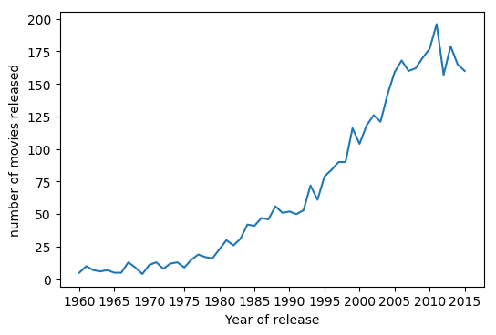

```python
plt.figure(dpi =100)

# x-label
plt.xlabel('Year of release')

# y-label
plt.ylabel('number of movies released')

plt.xticks(np.arange(1960, 2016 , 5))

plt.plot(highest_year)

plt.show()
```

```python
# Highest year in movie production
highest_year.idxmax()
```

```
2011
```

```python
# Lowest year in movie production
highest_year.idxmin()
```

```
1969
```

We can see here from this line plot there has been a siginficant increase in movie production over the years where 2011 had the highest number of movies produced and 1969 had the lowest

### 3 - Which runtime is most liked by the audiences according to their popularity?

```python
length_vote = df.groupby('runtime')['popularity'].mean()
```

```python
length_vote.head()
```

```
runtime
15.0    0.208637
26.0    0.592219
63.0    1.425344
66.0    1.117300
69.0    1.101103
Name: popularity, dtype: float64
```

[figure not shown]

```python
# Size of the plot
plt.figure(dpi =100)

# x-label
plt.xlabel('runtime')

# y-label
plt.ylabel('popularity')

#plot title
plt.title('Runtime Vs Popularity')

#Setting range for x-axis for to make data better readability
plt.xticks(np.arange(0, 800 , 100))

plt.plot(length_vote)
plt.show()
```

as we can see here movies between 100 and 200 minutes are the most popular among people

### 4 - What is the Average Runtime Of Movies From Year To Year?

```python
runtime_year = df.groupby('release_year')['runtime'].mean()
runtime_year.head()
```

```
release_year
1960    130.000000
1961    132.500000
1962    141.285714
1963    153.500000
1964    122.428571
Name: runtime, dtype: float64
```

```python
#Highest runtime year
runtime_year.idxmax()
```

```
1965
```

```python
#Lowest runtime year
runtime_year.idxmin()
```

```
1987
```

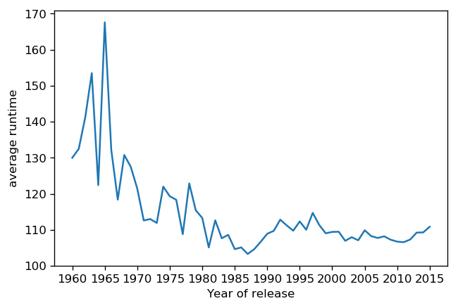

```python
plt.figure(dpi =120)

# x-label
plt.xlabel('Year of release')

# y-label
plt.ylabel('average runtime')

# setting range for x-axis to display all the years properly
plt.xticks(np.arange(1960, 2016 , 5))

plt.plot(runtime_year)
plt.show()
```

As we can see here in the plot average runtime of movies decreased over the years where the year which had highest average runtime is 1965 and lowest average runtime is 1987

### 5 - Is the rating of movies getting better or worse or staying the same over time?

```python
vote_release = df.groupby('release_year')['vote_average'].mean()
```

```python
#Year which had the highest average vote
vote_release.idxmax()
```

```
1960
```

```python
#Year which had the lowest average vote
vote_release.idxmin()
```

```
2000
```

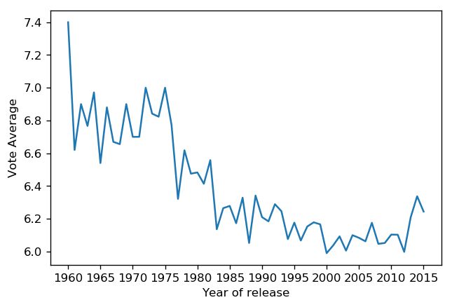

```python
plt.figure(dpi =120)

# x-label
plt.xlabel('Year of release')

# y-label
plt.ylabel('Vote Average')

# setting range for x-axis to display all the years properly
plt.xticks(np.arange(1960, 2016 , 5))

plt.plot(vote_release)
plt.show()
```

as we can see in the plot the average rating of movies decreases as years pass.The year which had the highest average rating is 1960 while the year that had the lowest is 2000

```python
rate_movie = df.groupby('original_title')['popularity'].mean()
```

```python
rate_movie.idxmax()
```

```
'Jurassic World'
```

### 7-What is the most popular genre over the years?

function to separate data in genres and count number of movies in each one

```python
def separate_count(column):
    split_data = pd.Series(df[column].str.cat(sep = '|').split('|'))

    count_data = split_data.value_counts(ascending=False)
    return count_data
```

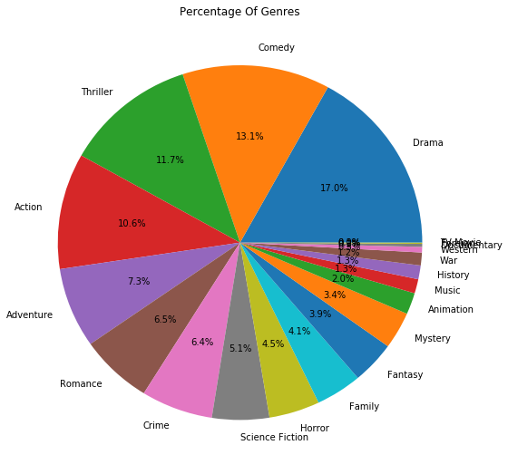

```python
#Plot a pie relationship between genre and number of movies
separate_count("genres").plot(kind="pie",figsize=(9,9),autopct="%1.1f%%")
# the title of the plot
plt.title('Percentage Of Genres')
plt.ylabel('');
```

As we can see in the plot above Drama is the most poplular over the years

## Conclusions

2-Movie ratings are getting worse overtime

4-Runtime decreased signficantly over the years

5-Average runtime of movies is 109 mins

6-Highest movie runtime year is 1965 while the lowest is 1987

7-Highest movie average vote year is 1960 while the lowest is 2000

8-2011 had the highest number of movies produced while 1969 had the lowest

9-There is a strong positive correlation between profit and revenue

10-As the budget for the movie increases the revenue increases

11-Drama is the most popular genre of movies

limitations: 1-budget and revenue had alot of zeroes also they do not have a currency

2-incorrect datatypes

3-i had to drop a lot of NA values

```python
from subprocess import call
call(['python', '-m', 'nbconvert', 'Investigate_a_Dataset.ipynb'])
```